# EDS241: Assignment 2

Heather Childers

2/9/2024

**Reminders:** Make sure to read through the setup in markdown. Remember to fully report/interpret your results and estimates (in writing) + present them in tables/plots.

# Part 1 Treatment Ignorability Assumption and Applying Matching Estimators (19 points):

The goal is to estimate the causal effect of maternal smoking during pregnancy on infant birth weight using the treatment ignorability assumptions. The data are taken from the National Natality Detail Files, and the extract “SMOKING_EDS241.csv”’ is a random sample of all births in Pennsylvania during 1989-1991. Each observation is a mother-infant pair. The key variables are:

**The outcome and treatment variables are:**

birthwgt=birth weight of infant in grams

tobacco=indicator for maternal smoking

**The control variables are:**

mage (mother’s age), meduc (mother’s education), mblack (=1 if mother identifies as Black), alcohol (=1 if consumed alcohol during pregnancy), first (=1 if first child), diabete (=1 if mother diabetic), anemia (=1 if mother anemic)

```r
# Load data for Part 1
data <- read_csv(here::here("Homework2", "data", "SMOKING_EDS241.csv"))
```

## Mean Differences, Assumptions, and Covariates *(3 pts) [Question A]*

1. **What is the mean difference in birth weight of infants with smoking and non-smoking mothers [1 pts]?**

   There is approximately a 245gram difference in the mean birth weights between non smoking and smoking mothers. The mean birthweight from non-smoking mothers is roughly 3430 grams and the mean birthweight from smoking mothers was roughly 3186grams. There is a significant difference between the mean birthweights with a p-value less than 0.001, this low p-value means we can reject the null-hypothesis that there is no difference in the mean birthweights between smoking and non-smoking mothers.

```r
smoking <- data %>%
  filter(tobacco == 1)
nonsmoking <- data %>%
  filter(tobacco == 0)

t.test(smoking$birthwgt, nonsmoking$birthwgt)
```

```
##
##  Welch Two Sample t-test
##
## data:  smoking$birthwgt and nonsmoking$birthwgt
## t = -58.932, df = 26945, p-value < 0.00000000000000022
## alternative hypothesis: true difference in means is not equal to 0
## 95 percent confidence interval:
##  -252.6727 -236.4060
## sample estimates:
## mean of x mean of y
##  3185.747  3430.286
```

```r
mean(nonsmoking$birthwgt)-mean(smoking$birthwgt)
```

```
## [1] 244.5394
```

2. **Under what assumption does this correspond to the average treatment effect of maternal smoking during pregnancy on infant birth weight [0.5 pts]?**

```r
# Selecting binary and continuous variables from the dataset
pretreat_binary <- data %>%
  select(anemia, diabete, alcohol, mblack, first, tobacco)
pretreat_continuous <- data %>%
  select(tobacco, mage, meduc, birthwgt)
control_binary <- data %>%
  select(anemia, diabete, alcohol, mblack, first)
control_continuous <- data %>%
  select(mage, meduc)

# Initialize empty data frames to store results of tests
prop_test_results <- data.frame()
t_test_results <- data.frame()

# Identifying binary variables for proportion tests
binary_vars <- names(control_binary)

for (var in binary_vars) {

# Splitting the data into treated and untreated groups for the current variable
treated <- pretreat_binary %>% filter(tobacco == 1) %>% pull(!!sym(var))
untreated <- pretreat_binary %>% filter(tobacco == 0) %>% pull(!!sym(var))

# Performing the proportion test
prop_test_result <- prop.test(x = c(sum(treated), sum(untreated)),
n = c(length(treated), length(untreated)),
correct = FALSE)

# Storing the tidy results of the proportion test in the data frame
prop_test_result_tidy <- broom::tidy(prop_test_result)
prop_test_result_tidy$Variable <- var
prop_test_results <- rbind(prop_test_results, prop_test_result_tidy)
}

# Identifying continuous variables for t-tests
continuous_vars <- names(control_continuous)

for (var in continuous_vars) {
# Dynamically creating the formula for the t-test
formula <- as.formula(paste(var, "~ tobacco"))
# Performing the t-test
t_test_result <- t.test(formula, data = pretreat_continuous)
# Storing the tidy results of the t-test in the data frame
t_test_result_tidy <- broom::tidy(t_test_result)
t_test_result_tidy$Variable <- var
t_test_results <- rbind(t_test_results, t_test_result_tidy)
}

# Combining the results of proportion and t-tests into a single data frame
combined_results <- bind_rows(
prop_test_results %>% select(Variable, estimate1, estimate2, p.value),
t_test_results %>% select(Variable, estimate1, estimate2, p.value)
)
# Creating a table for output using kable and kableExtra
combined_results_table <- kable(combined_results, format = "html",
                                col.names = c("Variable",
                                              "Proportion or Mean Control",
                                              "Proportion or Mean Treated", "P-Value"),
                                caption = "Treated and Untreated Pre-treatment Proportion and T-Test Results") %>%
                                kable_styling(font_size = 18)
# Displaying the table
combined_results_table
```

Treated and Untreated Pre-treatment Proportion and T-Test Results

[output not shown]

## ATE and Covariate Balance *(3 pts) [Question B]*

2. **Assume that maternal smoking is randomly assigned conditional on the observable covariates listed above. Estimate the effect of maternal smoking on birth weight using an OLS regression with NO linear controls for the covariates [0.5 pts].**

Using a linear regression model with no linear controls, the effect of smoking on maternal birthweights is -244grams with a p-value of less than 0.001. This implies that the differences in birthweights is significant enough that we can reject the null-hypothesis that there is no difference in the mean birth weights.

```r
# ATE Regression univariate
regression_1 <- lm(birthwgt ~ tobacco, data = data)
sjPlot::tab_model(regression_1)
```

|  | birthwgt |  |  |
| --- | --- | --- | --- |
| Predictors | Estimates | CI | p |
| (Intercept) | 3430.29 | 3426.78 – 3433.80 | **<0.001** |
| tobacco | -244.54 | -252.53 – -236.54 | **<0.001** |
| Observations | 94173 |  |  |
| R<sup>2</sup> / R<sup>2</sup> adjusted | 0.037 / 0.037 |  |  |

2. **Perform the same estimate including the control variables [0.5 pts].**

```r
# ATE with covariates
regression_2 <- lm(birthwgt ~ tobacco + anemia+ diabete + alcohol + mblack + first + mage + meduc, data = data)
sjPlot::tab_model(summary(regression_2))
```

|  | birthwgt |  |  |
| --- | --- | --- | --- |
| Predictors | Estimates | CI | p |
| (Intercept) | 3362.26 | 3338.88 – 3385.64 | **<0.001** |
| tobacco | -228.07 | -236.26 – -219.89 | **<0.001** |
| anemia | -4.80 | -37.63 – 28.04 | 0.775 |
| diabete | 73.23 | 49.50 – 96.95 | **<0.001** |
| alcohol | -77.35 | -103.74 – -50.96 | **<0.001** |
| mblack | -240.03 | -250.04 – -230.02 | **<0.001** |
| first | -96.94 | -103.70 – -90.19 | **<0.001** |
| mage | -0.69 | -1.39 – 0.00 | 0.052 |
| meduc | 11.69 | 10.00 – 13.37 | **<0.001** |
| Observations | 94173 |  |  |
| R<sup>2</sup> / R<sup>2</sup> adjusted | 0.072 / 0.072 |  |  |

2. **Next, compute indices of covariate imbalance between the treated and non-treated regarding these covariates (see example file from class). Present your results in a table [1 pts].**

```r
# Covariate imbalance
cov_imbal <- xBalance(tobacco ~  anemia+ diabete + alcohol + mblack + first + mage + meduc, data = data,
         report=c("std.diffs","chisquare.test", "p.values"))

# Balance Table
kable(cov_imbal$results, format = "html",
                                col.names = c("std.diffs",
                                              "chi-squared test",
                                              "p.values"),
                                caption = "Indices of Covariate Imbalance Between the Treated and Non-treated") %>%
  kable_styling(font_size = 18, full_width = TRUE)
```

Indices of Covariate Imbalance Between the Treated and Non-treated

| std.diffs | chi-squared test | p.values |
| --- | --- | --- |
| anemia | 0.0667029 | 0.0000000 |
| diabete | 0.0011864 | 0.8858011 |
| alcohol | 0.3152545 | 0.0000000 |
| mblack | 0.0843904 | 0.0000000 |
| first | -0.1449975 | 0.0000000 |
| mage | -0.3619420 | 0.0000000 |
| meduc | -0.6437354 | 0.0000000 |

2. **What do you find and what does it say regarding whether the assumption you mentioned responding to a) is fulfilled? [1 pts]**

Based on the results from these analyses, the characteristics of the treatment and the control groups are not equal, so we should be worried that there are some underlying characteristics that we did not account for in our first assessment of the means that might be affecting the birth weights between smoking and non-smoking mothers.

## Propensity Score Estimation *(3 pts) [Question C]*

5. **Next, estimate propensity scores (i.e. probability of being treated) for the sample, using the provided covariates. Create a regression table reporting the results of the regression and discuss what the covariate coefficients indicate and interpret one coefficient [1.5 pts].**

```r
## Propensity Scores
ps <- glm(tobacco ~ anemia+ diabete + alcohol + mblack + first + mage + meduc,
        data = data, family = binomial())
summary(ps)
```

```
##
## Call:
## glm(formula = tobacco ~ anemia + diabete + alcohol + mblack +
##     first + mage + meduc, family = binomial(), data = data)
##
## Coefficients:
##              Estimate Std. Error z value             Pr(>|z|)
## (Intercept)  3.493297   0.066613  52.442 < 0.0000000000000002 ***
## anemia       0.333952   0.079367   4.208          0.000025797 ***
## diabete      0.159533   0.065861   2.422               0.0154 *
## alcohol      2.026641   0.060353  33.580 < 0.0000000000000002 ***
## mblack      -0.133447   0.026587  -5.019          0.000000519 ***
## first       -0.379167   0.019303 -19.643 < 0.0000000000000002 ***
## mage        -0.040562   0.001931 -21.007 < 0.0000000000000002 ***
## meduc       -0.297269   0.005152 -57.699 < 0.0000000000000002 ***
## ---
## Signif. codes:  0 '***' 0.001 '**' 0.01 '*' 0.05 '.' 0.1 ' ' 1
##
## (Dispersion parameter for binomial family taken to be 1)
##
##     Null deviance: 92325  on 94172  degrees of freedom
## Residual deviance: 84459  on 94165  degrees of freedom
## AIC: 84475
##
## Number of Fisher Scoring iterations: 5
```

```r
sjPlot::tab_model(ps)
```

|  | tobacco |  |  |
| --- | --- | --- | --- |
| Predictors | Odds Ratios | CI | p |
| (Intercept) | 32.89 | 28.87 – 37.49 | **<0.001** |
| anemia | 1.40 | 1.19 – 1.63 | **<0.001** |
| diabete | 1.17 | 1.03 – 1.33 | **0.015** |
| alcohol | 7.59 | 6.74 – 8.54 | **<0.001** |
| mblack | 0.88 | 0.83 – 0.92 | **<0.001** |
| first | 0.68 | 0.66 – 0.71 | **<0.001** |
| mage | 0.96 | 0.96 – 0.96 | **<0.001** |
| meduc | 0.74 | 0.74 – 0.75 | **<0.001** |
| Observations | 94173 |  |  |
| R<sup>2</sup> Tjur | 0.083 |  |  |

```r
data$psvalue <- predict(ps, type    = "response")
```

5. **Create histograms of the propensity scores comparing the distributions of propensity scores for smokers (‘treated’) and non-smokers (‘control’), discuss the overlap and what it means [1.5 pts].**

This histogram shows a lot of overlap between the two distributions, most notably it looks like there are mostly enough individuals in each of the propensity score bins to match with an equal scoring individual in the control group (except for very high propensity scores). These large sections of overlap make it believable they there was a reasonably valid counter factual for each member of the treated group.

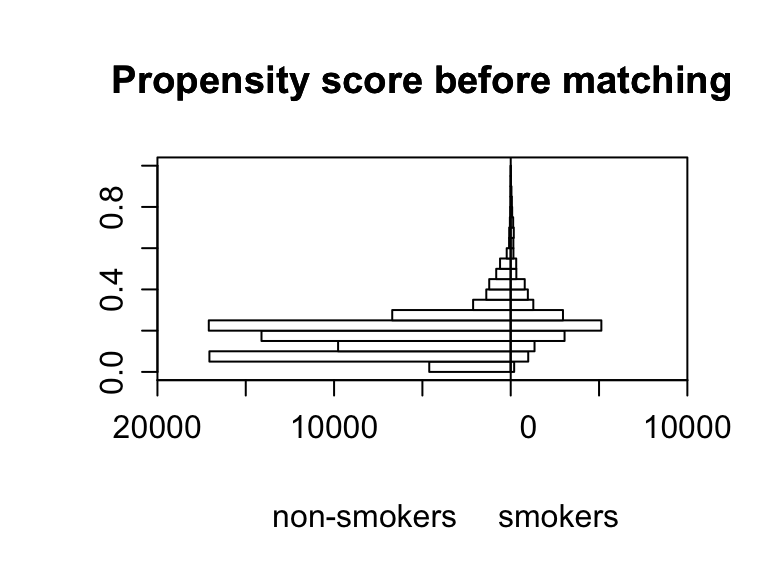

```r
## PS Histogram Unmatched
histbackback(split(data$psvalue, data$tobacco), main=
  "Propensity score before matching", xlab=c("non-smokers", "smokers"))
```

## Matching Balance *(3 pts) [Question D]*

4. Next, match treated/control mothers using your estimated propensity scores and nearest neighbor matching. Compare the balancing of pre-treatment characteristics (covariates) between treated and non-treated units in the original dataset (from c) with the matched dataset (think about comparing histograms/regressions) [2 pts].
5. Make sure to report and discuss the balance statistics [1 pts].

For looking at the difference in the characteristics between the treatment and non-treatment group post-matching, there are far fewer significant difference in the pre-treatment characteristics. The difference in the anemia pre-treatment characteristic between the smaoking and non-smoking mothers was 0.006, which a p-value of 0.55 which is too high to reject the null hypothesis that there is no significant difference in the means. The difference in the diabete pre-treatment characteristic between the smoking and non-smoking mothers was 0.002, which a p-value of 0.84 which is too high to reject the null hypothesis that there is no significant difference in the means. The difference in the mblack pre-treatment characteristic between the smoking and non-smoking mothers was 0.01, which a p-value of 0.32 which is too high to reject the null hypothesis that there is no significant difference in the means.The difference in the first pre-treatment characteristic between the smoking and non-smoking mothers was 0.0009, which a p-value of 0.93 which is too high to reject the null hypothesis that there is no significant difference in the means. The difference in the mage pre-treatment characteristic between the smoking and non-smoking mothers was 0.009, which a p-value of 0.36 which is too high to reject the null hypothesis that there is no significant difference in the means. There are still two pre-treatment characteristics that had small but significant differences in their means: the alcohol and education charcateristics. The difference in the alcohol pre-treatment characteristic between the smoking and non-smoking mothers was 0.11, which a p-value less than 0.001 which is low enough that we fail reject the null hypothesis that there is no significant difference in the means. The difference in the meduc pre-treatment characteristic between the smoking and non-smoking mothers was 0.04, which a p-value less than 0.001 which is low enough that we fail reject the null hypothesis that there is no significant difference in the means. Furthurmore we can see from the post-matching histogram, we’ve selected roughly an equal number of people from the control group as we had in the treatment group for each of the bins. As I mentioned in the initial histogram, you can see there are less available matches in the higher propensity scores so you can see that between the ~0.5-0.6 propensity score values there are more selection from the control group to match to the higher propensity scores in the treated group. Overall since the distribution of propensity scores are roughly equal for the treated and non-treated groups, we can believe there were valid counter factuals for this observational study.

```r
## Nearest-neighbor Matching
m.nn    <- matchit(tobacco ~ anemia + diabete + alcohol + mblack + first + mage + meduc,
        data = data, method = "nearest", ratio = 1)
summary(m.nn)
```

```
##
## Call:
## matchit(formula = tobacco ~ anemia + diabete + alcohol + mblack +
##     first + mage + meduc, data = data, method = "nearest", ratio = 1)
##
## Summary of Balance for All Data:
##          Means Treated Means Control Std. Mean Diff. Var. Ratio eCDF Mean
## distance        0.2600        0.1767          0.6190     1.6361    0.1402
## anemia          0.0141        0.0078          0.0535          .    0.0063
## diabete         0.0175        0.0174          0.0012          .    0.0002
## alcohol         0.0442        0.0071          0.1804          .    0.0371
## mblack          0.1354        0.1086          0.0783          .    0.0268
## first           0.3646        0.4361         -0.1486          .    0.0715
## mage           25.5386       27.4531         -0.3663     0.9709    0.0766
## meduc          11.9209       13.2394         -0.8190     0.5662    0.0734
##          eCDF Max
## distance   0.2945
## anemia     0.0063
## diabete    0.0002
## alcohol    0.0371
## mblack     0.0268
## first      0.0715
## mage       0.1676
## meduc      0.2773
##
## Summary of Balance for Matched Data:
##          Means Treated Means Control Std. Mean Diff. Var. Ratio eCDF Mean
## distance        0.2600        0.2560          0.0299     1.2066    0.0024
## anemia          0.0141        0.0134          0.0061          .    0.0007
## diabete         0.0175        0.0172          0.0021          .    0.0003
## alcohol         0.0442        0.0240          0.0984          .    0.0202
## mblack          0.1354        0.1319          0.0103          .    0.0035
## first           0.3646        0.3641          0.0009          .    0.0004
## mage           25.5386       25.4882          0.0096     1.0004    0.0021
## meduc          11.9209       11.8534          0.0420     0.8306    0.0051
##          eCDF Max Std. Pair Dist.
## distance   0.0218          0.0300
## anemia     0.0007          0.1070
## diabete    0.0003          0.0718
## alcohol    0.0202          0.1670
## mblack     0.0035          0.0982
## first      0.0004          0.0989
## mage       0.0071          0.1030
## meduc      0.0256          0.1443
##
## Sample Sizes:
##           Control Treated
## All         76021   18152
## Matched     18152   18152
## Unmatched   57869       0
## Discarded       0       0
```

```r
match.data = match.data(m.nn)

## Covariate Imbalance post matching:
post_match <- xBalance(tobacco ~  anemia+ diabete + alcohol + mblack + first + mage + meduc, data = match.data,
         report=c("std.diffs","chisquare.test", "p.values"))
# Balance Table
kable(post_match$results, format = "html",
                                col.names = c("std.diffs",
                                              "chi-squared test",
                                              "p.values"),
                                caption = "Indices of Covariate Imbalance Between the Treated and Non-treated after Matching") %>%
  kable_styling(font_size = 18, full_width = TRUE)
```

Indices of Covariate Imbalance Between the Treated and Non-treated after Matching

| std.diffs | chi-squared test | p.values |
| --- | --- | --- |
| anemia | 0.0061509 | 0.5578802 |
| diabete | 0.0021077 | 0.8408575 |
| alcohol | 0.1116157 | 0.0000000 |
| mblack | 0.0103614 | 0.3235874 |
| first | 0.0009158 | 0.9304778 |
| mage | 0.0096451 | 0.3581627 |
| meduc | 0.0399657 | 0.0001408 |

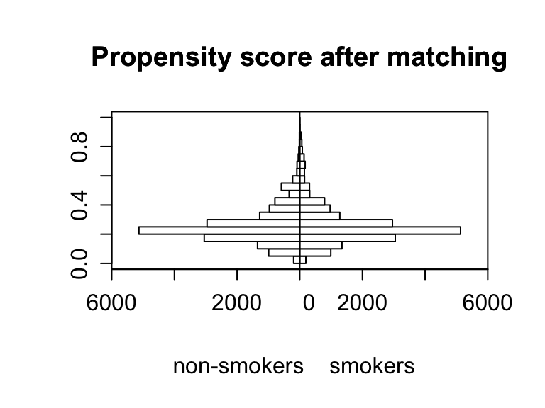

```r
## Histogram of PS after matching
histbackback(split(match.data$psvalue, match.data$tobacco), main=
  "Propensity score after matching", xlab=c("non-smokers", "smokers"))
```

## ATT with Nearest Neighbor *(3 pts) [Question E]*

5. Estimate the ATT using the matched dataset. **Report and interpret your result** (Note: no standard error or significance test is required here)

When looking at just the matched data, we were able to see that maternal smoking caused a 223 gram decrease in birthweights. This shows us that there were some pre-treatment characteristics from anemia, diabete, mblack, first, and mage that were artificially lowering our ATE estimate. It’s worth noting that this is still a slightly biased esitmate for ATT because there were still small but significant differences in the pre-treatment characteristics for alcohol and education.

```r
## Nearest Neighbor
sumdiff_data<-match.data%>%
  group_by(subclass)%>%
  mutate(diff=birthwgt[tobacco==1]-birthwgt[tobacco==0])


## ATT
NT = sum(smoking$tobacco)
sumdiff<-sum(sumdiff_data$diff)/2
ATT_m_nn = 1/NT * sumdiff
ATT_m_nn
```

```
## [1] -222.9365
```

## ATE with WLS Matching *(3 pts) [Question F]*

6. Last, use the original dataset and perform the weighted least squares estimation of the ATE using the propensity scores (including controls). Report and interpret your results, here include both size and precision of estimate in reporting and interpretation.

```r
## Weighted least Squares (WLS) estimator Preparation
PS <- data$psvalue
Y <- data$birthwgt
D <- data$tobacco
EY1 <- D*Y/PS / sum(D/PS)
EY0 <- (1-D)*Y/(1-PS) / sum((1-D) / (1-PS))
ATE_IPW = sum(EY1) - sum(EY0)
ATE_IPW
```

```
## [1] -231.3871
```

```r
data$wgt = (D/PS + (1-D)/(1-PS))
## Weighted least Squares (WLS) Estimates
reg_wls <-lm(tobacco ~  anemia+ diabete + alcohol + mblack + first + mage + meduc,
          data = data, weights = wgt)


## Present Results
sjPlot::tab_model(summary(reg_wls))
```

|  | tobacco |  |  |
| --- | --- | --- | --- |
| Predictors | Estimates | CI | p |
| (Intercept) | 0.55 | 0.53 – 0.57 | **<0.001** |
| anemia | 0.00 | -0.03 – 0.04 | 0.768 |
| diabete | 0.01 | -0.01 – 0.04 | 0.325 |
| alcohol | -0.00 | -0.03 – 0.03 | 0.982 |
| mblack | 0.04 | 0.03 – 0.05 | **<0.001** |
| first | 0.02 | 0.01 – 0.03 | **<0.001** |
| mage | 0.00 | 0.00 – 0.00 | **<0.001** |
| meduc | -0.01 | -0.01 – -0.01 | **<0.001** |
| Observations | 94173 |  |  |
| R<sup>2</sup> / R<sup>2</sup> adjusted | 0.003 / 0.003 |  |  |

## Differences in Estimates *(1 pts)*

7. Explain why it was to be expected given your analysis above that there is a difference between your estimates in e) and f)?

it was expected that we found difference in our estimates for questions e and f because in question e we are calculating the Average Treatment effect on the Treated, but in question f we are calculating the Average Treatment Effect. These will almost always be different when we have difference in the characteristics between the treatment and control group.

# Part 2 Panel model and fixed effects (6 points)

We will use the progresa data from last time as well as a new dataset. In the original dataset, treatment households had been receiving the transfer for a year. Now, you get an additional dataset with information on the same households from before the program was implemented, establishing a baseline study (from 1997), and the same data we worked with last time (from 1999). *Note: You will need to install the packages plm and dplyr (included in template preamble). Again, you can find a description of the variables at the bottom of PDF and HERE.

## Estimating Effect with First Difference *(3 pts: 1.5 pts estimate, 1.5 pts interpretation)*

Setup: Load the new baseline data (progresa_pre_1997.csv) and the follow-up data (progresa_post_1999.csv) into R. Note that we created a time denoting variable (with the same name, ‘year’) in BOTH datasets. Then, create a panel dataset by appending the data (i.e. binding the dataset row-wise together creating a single dataset). We want to examine the same outcome variable as before, value of animal holdings (vani).

```r
rm(list=ls()) # clean environment

## Load the datasets
progresa_pre_1997 <- read_csv(here::here("Homework2", "data","progresa_pre_1997.csv"))
progresa_post_1999 <- read_csv(here::here("Homework2","data","progresa_post_1999.csv"))

## Append post to pre dataset
progresa <- rbind(progresa_pre_1997, progresa_post_1999)
```

1. Estimate a first-difference (FD) regression manually, interpret the results briefly (size of coefficient and precision!) *Note: Calculate the difference between pre- and post- program outcomes for each family. To do that, follow these steps and the code given in the R-template:

```r
### Code included to help get you started
## i. Sort the panel data in the order in which you want to take differences, i.e. by household and time.
 progresa_full <- progresa %>%
   arrange(hhid, year) %>%
   group_by(hhid) %>%
  mutate(vani_fd = vani - dplyr::lag(vani))

## Create first differences of variables
## ii. Calculate the first difference using the lag function from the dplyr package.

## iii. Estimate manual first-difference regression (Estimate the regression using the newly created variables.)
fd_manual <- lm(formula = vani_fd ~ treatment, data = progresa_full)
sjPlot::tab_model(fd_manual)
```

|  | vani fd |  |  |
| --- | --- | --- | --- |
| Predictors | Estimates | CI | p |
| (Intercept) | -1156.75 | -1283.17 – -1030.33 | **<0.001** |
| treatment | 287.90 | 120.11 – 455.70 | **0.001** |
| Observations | 13514 |  |  |
| R<sup>2</sup> / R<sup>2</sup> adjusted | 0.001 / 0.001 |  |  |

## Fixed Effects Estimates *(2 pts: 1 pts estimate, 1.5 interpretation)*

2. Now also run a fixed effects (FE or ‘within’) regression and compare the results. Interpret the estimated treatment effects briefly (size of coefficient and precision!)

```r
## Fixed Effects Regression
# ESTIMATE THE BASIC 'WITHIN' FIXED EFFECTS REGRESSION
# NOTE "plm" ONLY PRODUCES CLUSTER-ROBUST STANDARD ERRORS

within1 <- plm(vani ~ treatment, model = "within", index = c("state", "year"),  effect = "twoways", data = progresa)

# Calculate standard errors (note slightly different procedure with plm package)
se_within1 <- coeftest(within1, vcov = vcovHC(within1, type = "HC2", method="white1"))[, "Std. Error"]
## Present Regression Results
se_within1 <- list(se_within1)
# Output results with stargazer
stargazer(within1, keep=c("treatment"), se = se_within1, type="text")
```

```
##
## ========================================
##                  Dependent variable:
##              ---------------------------
##                         vani
## ----------------------------------------
## treatment            -231.844***
##                       (56.662)
##
## ----------------------------------------
## Observations           27,996
## R2                      0.001
## Adjusted R2            0.0003
## F Statistic   17.206*** (df = 1; 27987)
## ========================================
## Note:        *p<0.1; **p<0.05; ***p<0.01
```

## First Difference and Fixed Effects and Omitted Variable Problems *(1 pts)*

3. Explain briefly how the FD and FE estimator solves a specific omitted variable problem? Look at the example on beer tax and traffic fatalities from class to start thinking about omitted variables. Give an example of a potential omitted variable for the example we are working with here that might confound our results? For that omitted variable, is a FE or FD estimator better? One example is enough.

The first difference and fixed effect estimators solve the problem of time-invariant, unobserved characteristics that affect the outcome variable causing biased estimates. By comparing datasets over time, we can account for the time invariant characteristics. An example of omitted variable bias in this example is property size, obviously the larger your property is, the more you benefit from a cash transfer program where you can put money into long term assets. I am assuming that no one used their cash trasfer to increase their property size (also the more property you have the more animal holdings you are likely to have). A first difference estimator should work well to solve this problem of a time-invariant variable becuase we only have two time periods and the distance between t1 and t2 is small.